# Risk Factor Analysis

## Outcome Variable

**Outcome Variable:** y_rate_haz

## Predictor Variables

**Intervention Variable:** predfeed6

**Adjustment Set:**

- arm
- sex
- month
- brthmon
- W_mage
- meducyrs
- feducyrs
- hhwealth_quart
- hfoodsec
- W_mhtcm
- vagbrth
- W_gagebrth
- W_birthwt
- W_birthlen
- W_nrooms
- W_nchldlt5
- W_parity
- impfloor
- impsan
- safeh20
- delta_W_mage
- delta_meducyrs
- delta_feducyrs
- delta_hhwealth_quart
- delta_hfoodsec
- delta_W_mhtcm
- delta_vagbrth
- delta_W_gagebrth
- delta_W_birthwt
- delta_W_birthlen
- delta_W_nrooms
- delta_W_nchldlt5
- delta_W_parity
- delta_impfloor
- delta_impsan
- delta_safeh20

## Stratifying Variables

The analysis was stratified on these variable(s):

- agecat
- studyid
- country

## Data Summary

| agecat | studyid | country | predfeed6 | n_cell | n |
| --- | --- | --- | --- | --- | --- |
| 0-3 months | ki0047075b-MAL-ED | BANGLADESH | 0 | 112 | 233 |
| 0-3 months | ki0047075b-MAL-ED | BANGLADESH | 1 | 121 | 233 |
| 0-3 months | ki0047075b-MAL-ED | BRAZIL | 0 | 148 | 175 |
| 0-3 months | ki0047075b-MAL-ED | BRAZIL | 1 | 27 | 175 |
| 0-3 months | ki0047075b-MAL-ED | INDIA | 0 | 178 | 193 |
| 0-3 months | ki0047075b-MAL-ED | INDIA | 1 | 15 | 193 |
| 0-3 months | ki0047075b-MAL-ED | NEPAL | 0 | 150 | 173 |
| 0-3 months | ki0047075b-MAL-ED | NEPAL | 1 | 23 | 173 |
| 0-3 months | ki0047075b-MAL-ED | PERU | 0 | 150 | 258 |
| 0-3 months | ki0047075b-MAL-ED | PERU | 1 | 108 | 258 |
| 0-3 months | ki0047075b-MAL-ED | SOUTH AFRICA | 0 | 206 | 209 |
| 0-3 months | ki0047075b-MAL-ED | SOUTH AFRICA | 1 | 3 | 209 |
| 0-3 months | ki0047075b-MAL-ED | TANZANIA, UNITED REPUBLIC OF | 0 | 223 | 224 |
| 0-3 months | ki0047075b-MAL-ED | TANZANIA, UNITED REPUBLIC OF | 1 | 1 | 224 |
| 0-3 months | ki1000109-EE | PAKISTAN | 0 | 260 | 594 |
| 0-3 months | ki1000109-EE | PAKISTAN | 1 | 334 | 594 |
| 0-3 months | kiGH5241-JiVitA-3 | BANGLADESH | 0 | 8676 | 40078 |
| 0-3 months | kiGH5241-JiVitA-3 | BANGLADESH | 1 | 31402 | 40078 |
| 0-3 months | kiGH5241-JiVitA-4 | BANGLADESH | 0 | 586 | 3610 |
| 0-3 months | kiGH5241-JiVitA-4 | BANGLADESH | 1 | 3024 | 3610 |
| 3-6 months | ki0047075b-MAL-ED | BANGLADESH | 0 | 108 | 225 |
| 3-6 months | ki0047075b-MAL-ED | BANGLADESH | 1 | 117 | 225 |
| 3-6 months | ki0047075b-MAL-ED | BRAZIL | 0 | 173 | 208 |
| 3-6 months | ki0047075b-MAL-ED | BRAZIL | 1 | 35 | 208 |
| 3-6 months | ki0047075b-MAL-ED | INDIA | 0 | 207 | 225 |
| 3-6 months | ki0047075b-MAL-ED | INDIA | 1 | 18 | 225 |
| 3-6 months | ki0047075b-MAL-ED | NEPAL | 0 | 205 | 232 |
| 3-6 months | ki0047075b-MAL-ED | NEPAL | 1 | 27 | 232 |
| 3-6 months | ki0047075b-MAL-ED | PERU | 0 | 153 | 264 |
| 3-6 months | ki0047075b-MAL-ED | PERU | 1 | 111 | 264 |

[output cut: 60 more lines]

The following strata were considered:

- agecat: 0-3 months, studyid: ki0047075b-MAL-ED, country: BANGLADESH
- agecat: 0-3 months, studyid: ki0047075b-MAL-ED, country: BRAZIL
- agecat: 0-3 months, studyid: ki0047075b-MAL-ED, country: INDIA
- agecat: 0-3 months, studyid: ki0047075b-MAL-ED, country: NEPAL
- agecat: 0-3 months, studyid: ki0047075b-MAL-ED, country: PERU
- agecat: 0-3 months, studyid: ki0047075b-MAL-ED, country: SOUTH AFRICA
- agecat: 0-3 months, studyid: ki0047075b-MAL-ED, country: TANZANIA, UNITED REPUBLIC OF
- agecat: 0-3 months, studyid: ki1000109-EE, country: PAKISTAN
- agecat: 0-3 months, studyid: kiGH5241-JiVitA-3, country: BANGLADESH
- agecat: 0-3 months, studyid: kiGH5241-JiVitA-4, country: BANGLADESH
- agecat: 12-24 months, studyid: ki0047075b-MAL-ED, country: BANGLADESH
- agecat: 12-24 months, studyid: ki0047075b-MAL-ED, country: BRAZIL
- agecat: 12-24 months, studyid: ki0047075b-MAL-ED, country: INDIA
- agecat: 12-24 months, studyid: ki0047075b-MAL-ED, country: NEPAL
- agecat: 12-24 months, studyid: ki0047075b-MAL-ED, country: PERU
- agecat: 12-24 months, studyid: ki0047075b-MAL-ED, country: SOUTH AFRICA
- agecat: 12-24 months, studyid: ki0047075b-MAL-ED, country: TANZANIA, UNITED REPUBLIC OF
- agecat: 12-24 months, studyid: ki1113344-GMS-Nepal, country: NEPAL
- agecat: 12-24 months, studyid: ki1148112-LCNI-5, country: MALAWI
- agecat: 12-24 months, studyid: kiGH5241-JiVitA-3, country: BANGLADESH
- agecat: 12-24 months, studyid: kiGH5241-JiVitA-4, country: BANGLADESH
- agecat: 3-6 months, studyid: ki0047075b-MAL-ED, country: BANGLADESH
- agecat: 3-6 months, studyid: ki0047075b-MAL-ED, country: BRAZIL
- agecat: 3-6 months, studyid: ki0047075b-MAL-ED, country: INDIA
- agecat: 3-6 months, studyid: ki0047075b-MAL-ED, country: NEPAL
- agecat: 3-6 months, studyid: ki0047075b-MAL-ED, country: PERU
- agecat: 3-6 months, studyid: ki0047075b-MAL-ED, country: SOUTH AFRICA
- agecat: 3-6 months, studyid: ki0047075b-MAL-ED, country: TANZANIA, UNITED REPUBLIC OF
- agecat: 3-6 months, studyid: ki1000109-EE, country: PAKISTAN
- agecat: 3-6 months, studyid: ki1113344-GMS-Nepal, country: NEPAL
- agecat: 3-6 months, studyid: kiGH5241-JiVitA-3, country: BANGLADESH
- agecat: 3-6 months, studyid: kiGH5241-JiVitA-4, country: BANGLADESH
- agecat: 6-12 months, studyid: ki0047075b-MAL-ED, country: BANGLADESH
- agecat: 6-12 months, studyid: ki0047075b-MAL-ED, country: BRAZIL
- agecat: 6-12 months, studyid: ki0047075b-MAL-ED, country: INDIA
- agecat: 6-12 months, studyid: ki0047075b-MAL-ED, country: NEPAL
- agecat: 6-12 months, studyid: ki0047075b-MAL-ED, country: PERU
- agecat: 6-12 months, studyid: ki0047075b-MAL-ED, country: SOUTH AFRICA
- agecat: 6-12 months, studyid: ki0047075b-MAL-ED, country: TANZANIA, UNITED REPUBLIC OF
- agecat: 6-12 months, studyid: ki1000109-EE, country: PAKISTAN
- agecat: 6-12 months, studyid: ki1000304b-SAS-FoodSuppl, country: INDIA
- agecat: 6-12 months, studyid: ki1113344-GMS-Nepal, country: NEPAL
- agecat: 6-12 months, studyid: ki1148112-LCNI-5, country: MALAWI
- agecat: 6-12 months, studyid: kiGH5241-JiVitA-3, country: BANGLADESH
- agecat: 6-12 months, studyid: kiGH5241-JiVitA-4, country: BANGLADESH

### Dropped Strata

Some strata were dropped due to rare outcomes:

- agecat: 0-3 months, studyid: ki0047075b-MAL-ED, country: SOUTH AFRICA
- agecat: 0-3 months, studyid: ki0047075b-MAL-ED, country: TANZANIA, UNITED REPUBLIC OF
- agecat: 3-6 months, studyid: ki0047075b-MAL-ED, country: SOUTH AFRICA
- agecat: 3-6 months, studyid: ki0047075b-MAL-ED, country: TANZANIA, UNITED REPUBLIC OF
- agecat: 6-12 months, studyid: ki0047075b-MAL-ED, country: SOUTH AFRICA
- agecat: 6-12 months, studyid: ki0047075b-MAL-ED, country: TANZANIA, UNITED REPUBLIC OF
- agecat: 6-12 months, studyid: ki1000109-EE, country: PAKISTAN
- agecat: 6-12 months, studyid: ki1000304b-SAS-FoodSuppl, country: INDIA
- agecat: 12-24 months, studyid: ki0047075b-MAL-ED, country: SOUTH AFRICA
- agecat: 12-24 months, studyid: ki0047075b-MAL-ED, country: TANZANIA, UNITED REPUBLIC OF

## Methods Detail

We’re interested in the causal parameters $E[Y_a]$ for all values of $a \in \mathcal{A}$. These parameters represent the mean outcome if, possibly contrary to fact, we intervened to set all units to have $A=a$. Under the randomization and positivity assumptions, these are identified by the statistical parameters $\psi_a=E_W[E_{Y|A,W}(Y|A=a,W)]$. In addition, we’re interested in the mean of $Y$, $E[Y]$ under no intervention (the observed mean). We will estimate these parameters by using SuperLearner to fit the relevant likelihood factors – $E_{Y|A,W}(Y|A=a,W)$ and $p(A=a|W)$, and then updating our likelihood fit using a joint TMLE.

For unadjusted analyses ($W=\{\}$), initial likelihoods were estimated using Lrnr_glm to estimate the simple $E(Y|A)$ and Lrnr_mean to estimate $p(A)$. For adjusted analyses, a small library containing Lrnr_glmnet, Lrnr_xgboost, and Lrnr_mean was used.

Having estimated these parameters, we will then use the delta method to estimate relative risks and attributable risks relative to a prespecified baseline level of $A$.

# Results Detail

## Results Plots

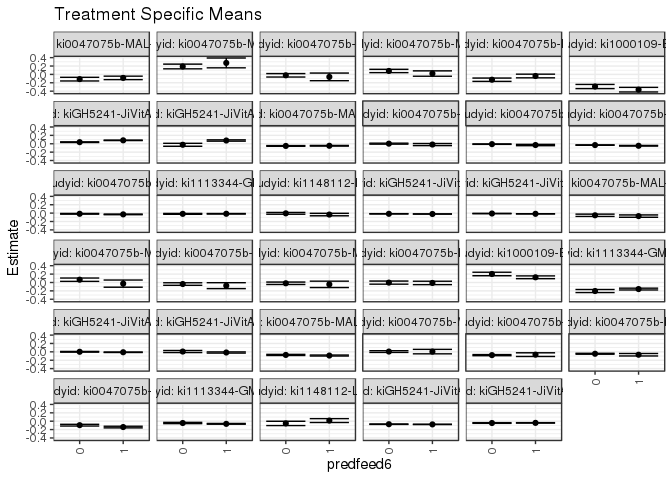

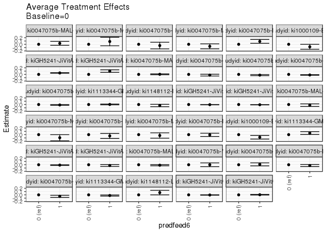

## Results Table

### Parameter: TSM

| agecat | studyid | country | intervention_level | baseline_level | estimate | ci_lower | ci_upper |
| --- | --- | --- | --- | --- | --- | --- | --- |
| 0-3 months | ki0047075b-MAL-ED | BANGLADESH | 0 | NA | -0.1130369 | -0.1565585 | -0.0695154 |
| 0-3 months | ki0047075b-MAL-ED | BANGLADESH | 1 | NA | -0.0834452 | -0.1250606 | -0.0418297 |
| 0-3 months | ki0047075b-MAL-ED | BRAZIL | 0 | NA | 0.1889411 | 0.1326303 | 0.2452519 |
| 0-3 months | ki0047075b-MAL-ED | BRAZIL | 1 | NA | 0.2738078 | 0.1561897 | 0.3914259 |
| 0-3 months | ki0047075b-MAL-ED | INDIA | 0 | NA | -0.0215058 | -0.0623348 | 0.0193233 |
| 0-3 months | ki0047075b-MAL-ED | INDIA | 1 | NA | -0.0592186 | -0.1503340 | 0.0318968 |
| 0-3 months | ki0047075b-MAL-ED | NEPAL | 0 | NA | 0.0817136 | 0.0423482 | 0.1210789 |
| 0-3 months | ki0047075b-MAL-ED | NEPAL | 1 | NA | 0.0201940 | -0.0439241 | 0.0843120 |
| 0-3 months | ki0047075b-MAL-ED | PERU | 0 | NA | -0.1271103 | -0.1667820 | -0.0874386 |
| 0-3 months | ki0047075b-MAL-ED | PERU | 1 | NA | -0.0384807 | -0.0820313 | 0.0050699 |
| 0-3 months | ki1000109-EE | PAKISTAN | 0 | NA | -0.2892077 | -0.3387035 | -0.2397118 |
| 0-3 months | ki1000109-EE | PAKISTAN | 1 | NA | -0.3642174 | -0.4192563 | -0.3091786 |
| 0-3 months | kiGH5241-JiVitA-3 | BANGLADESH | 0 | NA | 0.0381155 | 0.0299626 | 0.0462684 |
| 0-3 months | kiGH5241-JiVitA-3 | BANGLADESH | 1 | NA | 0.0819091 | 0.0766966 | 0.0871217 |
| 0-3 months | kiGH5241-JiVitA-4 | BANGLADESH | 0 | NA | -0.0242712 | -0.0595734 | 0.0110310 |
| 0-3 months | kiGH5241-JiVitA-4 | BANGLADESH | 1 | NA | 0.0774575 | 0.0618642 | 0.0930508 |
| 3-6 months | ki0047075b-MAL-ED | BANGLADESH | 0 | NA | -0.0517014 | -0.0792152 | -0.0241876 |
| 3-6 months | ki0047075b-MAL-ED | BANGLADESH | 1 | NA | -0.0711414 | -0.0989048 | -0.0433780 |
| 3-6 months | ki0047075b-MAL-ED | BRAZIL | 0 | NA | 0.0665154 | 0.0270711 | 0.1059598 |
| 3-6 months | ki0047075b-MAL-ED | BRAZIL | 1 | NA | -0.0273800 | -0.1126452 | 0.0578853 |
| 3-6 months | ki0047075b-MAL-ED | INDIA | 0 | NA | -0.0369367 | -0.0673811 | -0.0064923 |
| 3-6 months | ki0047075b-MAL-ED | INDIA | 1 | NA | -0.0758275 | -0.1462718 | -0.0053832 |
| 3-6 months | ki0047075b-MAL-ED | NEPAL | 0 | NA | -0.0186830 | -0.0471850 | 0.0098189 |
| 3-6 months | ki0047075b-MAL-ED | NEPAL | 1 | NA | -0.0447744 | -0.1204223 | 0.0308736 |
| 3-6 months | ki0047075b-MAL-ED | PERU | 0 | NA | -0.0033277 | -0.0404787 | 0.0338234 |
| 3-6 months | ki0047075b-MAL-ED | PERU | 1 | NA | -0.0110485 | -0.0518760 | 0.0297790 |
| 3-6 months | ki1000109-EE | PAKISTAN | 0 | NA | 0.2029001 | 0.1609782 | 0.2448221 |
| 3-6 months | ki1000109-EE | PAKISTAN | 1 | NA | 0.1237963 | 0.0910086 | 0.1565840 |
| 3-6 months | ki1113344-GMS-Nepal | NEPAL | 0 | NA | -0.2039630 | -0.2402300 | -0.1676960 |
| 3-6 months | ki1113344-GMS-Nepal | NEPAL | 1 | NA | -0.1569603 | -0.1781291 | -0.1357914 |
| 3-6 months | kiGH5241-JiVitA-3 | BANGLADESH | 0 | NA | 0.0013594 | -0.0071300 | 0.0098488 |
| 3-6 months | kiGH5241-JiVitA-3 | BANGLADESH | 1 | NA | -0.0096314 | -0.0148395 | -0.0044232 |
| 3-6 months | kiGH5241-JiVitA-4 | BANGLADESH | 0 | NA | 0.0071575 | -0.0176572 | 0.0319723 |
| 3-6 months | kiGH5241-JiVitA-4 | BANGLADESH | 1 | NA | -0.0157664 | -0.0305502 | -0.0009826 |
| 6-12 months | ki0047075b-MAL-ED | BANGLADESH | 0 | NA | -0.0737992 | -0.0871460 | -0.0604524 |
| 6-12 months | ki0047075b-MAL-ED | BANGLADESH | 1 | NA | -0.0885378 | -0.1003705 | -0.0767051 |
| 6-12 months | ki0047075b-MAL-ED | BRAZIL | 0 | NA | 0.0067834 | -0.0139950 | 0.0275617 |
| 6-12 months | ki0047075b-MAL-ED | BRAZIL | 1 | NA | 0.0054963 | -0.0478101 | 0.0588027 |
| 6-12 months | ki0047075b-MAL-ED | INDIA | 0 | NA | -0.0784101 | -0.0912667 | -0.0655534 |
| 6-12 months | ki0047075b-MAL-ED | INDIA | 1 | NA | -0.0666992 | -0.1103021 | -0.0230963 |
| 6-12 months | ki0047075b-MAL-ED | NEPAL | 0 | NA | -0.0456719 | -0.0569527 | -0.0343911 |
| 6-12 months | ki0047075b-MAL-ED | NEPAL | 1 | NA | -0.0691079 | -0.0990197 | -0.0391961 |
| 6-12 months | ki0047075b-MAL-ED | PERU | 0 | NA | -0.0946061 | -0.1152689 | -0.0739433 |
| 6-12 months | ki0047075b-MAL-ED | PERU | 1 | NA | -0.1395761 | -0.1593163 | -0.1198358 |
| 6-12 months | ki1113344-GMS-Nepal | NEPAL | 0 | NA | -0.0433074 | -0.0578883 | -0.0287265 |
| 6-12 months | ki1113344-GMS-Nepal | NEPAL | 1 | NA | -0.0632649 | -0.0724837 | -0.0540460 |
| 6-12 months | ki1148112-LCNI-5 | MALAWI | 0 | NA | -0.0529763 | -0.1045727 | -0.0013799 |
| 6-12 months | ki1148112-LCNI-5 | MALAWI | 1 | NA | 0.0151695 | -0.0305307 | 0.0608697 |
| 6-12 months | kiGH5241-JiVitA-3 | BANGLADESH | 0 | NA | -0.0719443 | -0.0771257 | -0.0667629 |
| 6-12 months | kiGH5241-JiVitA-3 | BANGLADESH | 1 | NA | -0.0763465 | -0.0793717 | -0.0733213 |
| 6-12 months | kiGH5241-JiVitA-4 | BANGLADESH | 0 | NA | -0.0433428 | -0.0516937 | -0.0349919 |
| 6-12 months | kiGH5241-JiVitA-4 | BANGLADESH | 1 | NA | -0.0399880 | -0.0450791 | -0.0348968 |
| 12-24 months | ki0047075b-MAL-ED | BANGLADESH | 0 | NA | -0.0520397 | -0.0608635 | -0.0432160 |
| 12-24 months | ki0047075b-MAL-ED | BANGLADESH | 1 | NA | -0.0481926 | -0.0557297 | -0.0406556 |
| 12-24 months | ki0047075b-MAL-ED | BRAZIL | 0 | NA | 0.0023702 | -0.0089960 | 0.0137365 |
| 12-24 months | ki0047075b-MAL-ED | BRAZIL | 1 | NA | -0.0185479 | -0.0438066 | 0.0067107 |
| 12-24 months | ki0047075b-MAL-ED | INDIA | 0 | NA | -0.0090699 | -0.0144593 | -0.0036805 |
| 12-24 months | ki0047075b-MAL-ED | INDIA | 1 | NA | -0.0302669 | -0.0465504 | -0.0139834 |
| 12-24 months | ki0047075b-MAL-ED | NEPAL | 0 | NA | -0.0312029 | -0.0366133 | -0.0257926 |
| 12-24 months | ki0047075b-MAL-ED | NEPAL | 1 | NA | -0.0481893 | -0.0560316 | -0.0403470 |
| 12-24 months | ki0047075b-MAL-ED | PERU | 0 | NA | -0.0160982 | -0.0251889 | -0.0070075 |
| 12-24 months | ki0047075b-MAL-ED | PERU | 1 | NA | -0.0297174 | -0.0376491 | -0.0217858 |
| 12-24 months | ki1113344-GMS-Nepal | NEPAL | 0 | NA | -0.0175177 | -0.0276022 | -0.0074331 |
| 12-24 months | ki1113344-GMS-Nepal | NEPAL | 1 | NA | -0.0154877 | -0.0213011 | -0.0096742 |
| 12-24 months | ki1148112-LCNI-5 | MALAWI | 0 | NA | -0.0053185 | -0.0263716 | 0.0157345 |
| 12-24 months | ki1148112-LCNI-5 | MALAWI | 1 | NA | -0.0345407 | -0.0639658 | -0.0051157 |
| 12-24 months | kiGH5241-JiVitA-3 | BANGLADESH | 0 | NA | -0.0163433 | -0.0195877 | -0.0130989 |
| 12-24 months | kiGH5241-JiVitA-3 | BANGLADESH | 1 | NA | -0.0208264 | -0.0227474 | -0.0189054 |
| 12-24 months | kiGH5241-JiVitA-4 | BANGLADESH | 0 | NA | -0.0097208 | -0.0128691 | -0.0065725 |
| 12-24 months | kiGH5241-JiVitA-4 | BANGLADESH | 1 | NA | -0.0164917 | -0.0186550 | -0.0143284 |

### Parameter: E(Y)

| agecat | studyid | country | intervention_level | baseline_level | estimate | ci_lower | ci_upper |
| --- | --- | --- | --- | --- | --- | --- | --- |
| 0-3 months | ki0047075b-MAL-ED | BANGLADESH | NA | NA | -0.0367999 | -0.0692784 | -0.0043215 |
| 0-3 months | ki0047075b-MAL-ED | BRAZIL | NA | NA | 0.2024499 | 0.1502269 | 0.2546728 |
| 0-3 months | ki0047075b-MAL-ED | INDIA | NA | NA | -0.0222752 | -0.0610481 | 0.0164977 |
| 0-3 months | ki0047075b-MAL-ED | NEPAL | NA | NA | 0.0735454 | 0.0381022 | 0.1089887 |
| 0-3 months | ki0047075b-MAL-ED | PERU | NA | NA | -0.1508658 | -0.1831247 | -0.1186070 |
| 0-3 months | ki1000109-EE | PAKISTAN | NA | NA | -0.3938516 | -0.4364614 | -0.3512419 |
| 0-3 months | kiGH5241-JiVitA-3 | BANGLADESH | NA | NA | 0.0705623 | 0.0656085 | 0.0755161 |
| 0-3 months | kiGH5241-JiVitA-4 | BANGLADESH | NA | NA | 0.0674700 | 0.0524969 | 0.0824432 |
| 3-6 months | ki0047075b-MAL-ED | BANGLADESH | NA | NA | -0.0188602 | -0.0422435 | 0.0045231 |
| 3-6 months | ki0047075b-MAL-ED | BRAZIL | NA | NA | 0.0604904 | 0.0239698 | 0.0970111 |
| 3-6 months | ki0047075b-MAL-ED | INDIA | NA | NA | -0.0402159 | -0.0690209 | -0.0114109 |
| 3-6 months | ki0047075b-MAL-ED | NEPAL | NA | NA | -0.0217195 | -0.0484207 | 0.0049817 |
| 3-6 months | ki0047075b-MAL-ED | PERU | NA | NA | 0.0285063 | -0.0025558 | 0.0595685 |
| 3-6 months | ki1000109-EE | PAKISTAN | NA | NA | 0.0701161 | 0.0419135 | 0.0983187 |
| 3-6 months | ki1113344-GMS-Nepal | NEPAL | NA | NA | -0.1663669 | -0.1850409 | -0.1476929 |
| 3-6 months | kiGH5241-JiVitA-3 | BANGLADESH | NA | NA | -0.0035176 | -0.0083841 | 0.0013489 |
| 3-6 months | kiGH5241-JiVitA-4 | BANGLADESH | NA | NA | -0.0095967 | -0.0234440 | 0.0042506 |
| 6-12 months | ki0047075b-MAL-ED | BANGLADESH | NA | NA | -0.0810302 | -0.0916713 | -0.0703891 |
| 6-12 months | ki0047075b-MAL-ED | BRAZIL | NA | NA | 0.0065644 | -0.0129183 | 0.0260472 |
| 6-12 months | ki0047075b-MAL-ED | INDIA | NA | NA | -0.0775092 | -0.0898591 | -0.0651592 |
| 6-12 months | ki0047075b-MAL-ED | NEPAL | NA | NA | -0.0484306 | -0.0591023 | -0.0377589 |
| 6-12 months | ki0047075b-MAL-ED | PERU | NA | NA | -0.0382822 | -0.0523761 | -0.0241883 |
| 6-12 months | ki1113344-GMS-Nepal | NEPAL | NA | NA | -0.0623284 | -0.0705747 | -0.0540821 |
| 6-12 months | ki1148112-LCNI-5 | MALAWI | NA | NA | -0.0281085 | -0.0675243 | 0.0113073 |
| 6-12 months | kiGH5241-JiVitA-3 | BANGLADESH | NA | NA | -0.0749683 | -0.0778180 | -0.0721186 |
| 6-12 months | kiGH5241-JiVitA-4 | BANGLADESH | NA | NA | -0.0387665 | -0.0435189 | -0.0340140 |
| 12-24 months | ki0047075b-MAL-ED | BANGLADESH | NA | NA | -0.0177288 | -0.0232009 | -0.0122567 |
| 12-24 months | ki0047075b-MAL-ED | BRAZIL | NA | NA | -0.0013016 | -0.0119070 | 0.0093038 |
| 12-24 months | ki0047075b-MAL-ED | INDIA | NA | NA | -0.0099239 | -0.0151132 | -0.0047346 |
| 12-24 months | ki0047075b-MAL-ED | NEPAL | NA | NA | -0.0297758 | -0.0348315 | -0.0247201 |
| 12-24 months | ki0047075b-MAL-ED | PERU | NA | NA | -0.0082368 | -0.0151828 | -0.0012908 |
| 12-24 months | ki1113344-GMS-Nepal | NEPAL | NA | NA | -0.0159785 | -0.0210905 | -0.0108666 |
| 12-24 months | ki1148112-LCNI-5 | MALAWI | NA | NA | -0.0140852 | -0.0319419 | 0.0037715 |
| 12-24 months | kiGH5241-JiVitA-3 | BANGLADESH | NA | NA | -0.0189940 | -0.0208299 | -0.0171580 |
| 12-24 months | kiGH5241-JiVitA-4 | BANGLADESH | NA | NA | -0.0145458 | -0.0165637 | -0.0125280 |

### Parameter: ATE

| agecat | studyid | country | intervention_level | baseline_level | estimate | ci_lower | ci_upper |
| --- | --- | --- | --- | --- | --- | --- | --- |
| 0-3 months | ki0047075b-MAL-ED | BANGLADESH | 0 | 0 | 0.0000000 | 0.0000000 | 0.0000000 |
| 0-3 months | ki0047075b-MAL-ED | BANGLADESH | 1 | 0 | 0.0295918 | -0.0295518 | 0.0887353 |
| 0-3 months | ki0047075b-MAL-ED | BRAZIL | 0 | 0 | 0.0000000 | 0.0000000 | 0.0000000 |
| 0-3 months | ki0047075b-MAL-ED | BRAZIL | 1 | 0 | 0.0848667 | -0.0452176 | 0.2149510 |
| 0-3 months | ki0047075b-MAL-ED | INDIA | 0 | 0 | 0.0000000 | 0.0000000 | 0.0000000 |
| 0-3 months | ki0047075b-MAL-ED | INDIA | 1 | 0 | -0.0377128 | -0.1377488 | 0.0623231 |
| 0-3 months | ki0047075b-MAL-ED | NEPAL | 0 | 0 | 0.0000000 | 0.0000000 | 0.0000000 |
| 0-3 months | ki0047075b-MAL-ED | NEPAL | 1 | 0 | -0.0615196 | -0.1363334 | 0.0132942 |
| 0-3 months | ki0047075b-MAL-ED | PERU | 0 | 0 | 0.0000000 | 0.0000000 | 0.0000000 |
| 0-3 months | ki0047075b-MAL-ED | PERU | 1 | 0 | 0.0886296 | 0.0300457 | 0.1472135 |
| 0-3 months | ki1000109-EE | PAKISTAN | 0 | 0 | 0.0000000 | 0.0000000 | 0.0000000 |
| 0-3 months | ki1000109-EE | PAKISTAN | 1 | 0 | -0.0750098 | -0.1498806 | -0.0001389 |
| 0-3 months | kiGH5241-JiVitA-3 | BANGLADESH | 0 | 0 | 0.0000000 | 0.0000000 | 0.0000000 |
| 0-3 months | kiGH5241-JiVitA-3 | BANGLADESH | 1 | 0 | 0.0437936 | 0.0351047 | 0.0524825 |
| 0-3 months | kiGH5241-JiVitA-4 | BANGLADESH | 0 | 0 | 0.0000000 | 0.0000000 | 0.0000000 |
| 0-3 months | kiGH5241-JiVitA-4 | BANGLADESH | 1 | 0 | 0.1017287 | 0.0633962 | 0.1400611 |
| 3-6 months | ki0047075b-MAL-ED | BANGLADESH | 0 | 0 | 0.0000000 | 0.0000000 | 0.0000000 |
| 3-6 months | ki0047075b-MAL-ED | BANGLADESH | 1 | 0 | -0.0194400 | -0.0587630 | 0.0198830 |
| 3-6 months | ki0047075b-MAL-ED | BRAZIL | 0 | 0 | 0.0000000 | 0.0000000 | 0.0000000 |
| 3-6 months | ki0047075b-MAL-ED | BRAZIL | 1 | 0 | -0.0938954 | -0.1868332 | -0.0009577 |
| 3-6 months | ki0047075b-MAL-ED | INDIA | 0 | 0 | 0.0000000 | 0.0000000 | 0.0000000 |
| 3-6 months | ki0047075b-MAL-ED | INDIA | 1 | 0 | -0.0388908 | -0.1163540 | 0.0385724 |
| 3-6 months | ki0047075b-MAL-ED | NEPAL | 0 | 0 | 0.0000000 | 0.0000000 | 0.0000000 |
| 3-6 months | ki0047075b-MAL-ED | NEPAL | 1 | 0 | -0.0260913 | -0.1069305 | 0.0547478 |
| 3-6 months | ki0047075b-MAL-ED | PERU | 0 | 0 | 0.0000000 | 0.0000000 | 0.0000000 |
| 3-6 months | ki0047075b-MAL-ED | PERU | 1 | 0 | -0.0077208 | -0.0582144 | 0.0427727 |
| 3-6 months | ki1000109-EE | PAKISTAN | 0 | 0 | 0.0000000 | 0.0000000 | 0.0000000 |
| 3-6 months | ki1000109-EE | PAKISTAN | 1 | 0 | -0.0791038 | -0.1340448 | -0.0241629 |
| 3-6 months | ki1113344-GMS-Nepal | NEPAL | 0 | 0 | 0.0000000 | 0.0000000 | 0.0000000 |
| 3-6 months | ki1113344-GMS-Nepal | NEPAL | 1 | 0 | 0.0470028 | 0.0050880 | 0.0889175 |
| 3-6 months | kiGH5241-JiVitA-3 | BANGLADESH | 0 | 0 | 0.0000000 | 0.0000000 | 0.0000000 |
| 3-6 months | kiGH5241-JiVitA-3 | BANGLADESH | 1 | 0 | -0.0109908 | -0.0203897 | -0.0015919 |
| 3-6 months | kiGH5241-JiVitA-4 | BANGLADESH | 0 | 0 | 0.0000000 | 0.0000000 | 0.0000000 |
| 3-6 months | kiGH5241-JiVitA-4 | BANGLADESH | 1 | 0 | -0.0229239 | -0.0505255 | 0.0046776 |
| 6-12 months | ki0047075b-MAL-ED | BANGLADESH | 0 | 0 | 0.0000000 | 0.0000000 | 0.0000000 |
| 6-12 months | ki0047075b-MAL-ED | BANGLADESH | 1 | 0 | -0.0147386 | -0.0322098 | 0.0027326 |
| 6-12 months | ki0047075b-MAL-ED | BRAZIL | 0 | 0 | 0.0000000 | 0.0000000 | 0.0000000 |
| 6-12 months | ki0047075b-MAL-ED | BRAZIL | 1 | 0 | -0.0012871 | -0.0584999 | 0.0559258 |
| 6-12 months | ki0047075b-MAL-ED | INDIA | 0 | 0 | 0.0000000 | 0.0000000 | 0.0000000 |
| 6-12 months | ki0047075b-MAL-ED | INDIA | 1 | 0 | 0.0117109 | -0.0337067 | 0.0571285 |
| 6-12 months | ki0047075b-MAL-ED | NEPAL | 0 | 0 | 0.0000000 | 0.0000000 | 0.0000000 |
| 6-12 months | ki0047075b-MAL-ED | NEPAL | 1 | 0 | -0.0234360 | -0.0551847 | 0.0083127 |
| 6-12 months | ki0047075b-MAL-ED | PERU | 0 | 0 | 0.0000000 | 0.0000000 | 0.0000000 |
| 6-12 months | ki0047075b-MAL-ED | PERU | 1 | 0 | -0.0449700 | -0.0766053 | -0.0133346 |
| 6-12 months | ki1113344-GMS-Nepal | NEPAL | 0 | 0 | 0.0000000 | 0.0000000 | 0.0000000 |
| 6-12 months | ki1113344-GMS-Nepal | NEPAL | 1 | 0 | -0.0199575 | -0.0371437 | -0.0027712 |
| 6-12 months | ki1148112-LCNI-5 | MALAWI | 0 | 0 | 0.0000000 | 0.0000000 | 0.0000000 |
| 6-12 months | ki1148112-LCNI-5 | MALAWI | 1 | 0 | 0.0681458 | -0.0008785 | 0.1371701 |
| 6-12 months | kiGH5241-JiVitA-3 | BANGLADESH | 0 | 0 | 0.0000000 | 0.0000000 | 0.0000000 |
| 6-12 months | kiGH5241-JiVitA-3 | BANGLADESH | 1 | 0 | -0.0044022 | -0.0100660 | 0.0012616 |
| 6-12 months | kiGH5241-JiVitA-4 | BANGLADESH | 0 | 0 | 0.0000000 | 0.0000000 | 0.0000000 |
| 6-12 months | kiGH5241-JiVitA-4 | BANGLADESH | 1 | 0 | 0.0033548 | -0.0060180 | 0.0127276 |
| 12-24 months | ki0047075b-MAL-ED | BANGLADESH | 0 | 0 | 0.0000000 | 0.0000000 | 0.0000000 |
| 12-24 months | ki0047075b-MAL-ED | BANGLADESH | 1 | 0 | 0.0038471 | -0.0091411 | 0.0168352 |
| 12-24 months | ki0047075b-MAL-ED | BRAZIL | 0 | 0 | 0.0000000 | 0.0000000 | 0.0000000 |
| 12-24 months | ki0047075b-MAL-ED | BRAZIL | 1 | 0 | -0.0209181 | -0.0482123 | 0.0063760 |
| 12-24 months | ki0047075b-MAL-ED | INDIA | 0 | 0 | 0.0000000 | 0.0000000 | 0.0000000 |
| 12-24 months | ki0047075b-MAL-ED | INDIA | 1 | 0 | -0.0211971 | -0.0383916 | -0.0040025 |
| 12-24 months | ki0047075b-MAL-ED | NEPAL | 0 | 0 | 0.0000000 | 0.0000000 | 0.0000000 |
| 12-24 months | ki0047075b-MAL-ED | NEPAL | 1 | 0 | -0.0169864 | -0.0265780 | -0.0073947 |
| 12-24 months | ki0047075b-MAL-ED | PERU | 0 | 0 | 0.0000000 | 0.0000000 | 0.0000000 |
| 12-24 months | ki0047075b-MAL-ED | PERU | 1 | 0 | -0.0136193 | -0.0258084 | -0.0014301 |
| 12-24 months | ki1113344-GMS-Nepal | NEPAL | 0 | 0 | 0.0000000 | 0.0000000 | 0.0000000 |
| 12-24 months | ki1113344-GMS-Nepal | NEPAL | 1 | 0 | 0.0020300 | -0.0094744 | 0.0135345 |
| 12-24 months | ki1148112-LCNI-5 | MALAWI | 0 | 0 | 0.0000000 | 0.0000000 | 0.0000000 |
| 12-24 months | ki1148112-LCNI-5 | MALAWI | 1 | 0 | -0.0292222 | -0.0654032 | 0.0069588 |
| 12-24 months | kiGH5241-JiVitA-3 | BANGLADESH | 0 | 0 | 0.0000000 | 0.0000000 | 0.0000000 |
| 12-24 months | kiGH5241-JiVitA-3 | BANGLADESH | 1 | 0 | -0.0044831 | -0.0080148 | -0.0009514 |
| 12-24 months | kiGH5241-JiVitA-4 | BANGLADESH | 0 | 0 | 0.0000000 | 0.0000000 | 0.0000000 |
| 12-24 months | kiGH5241-JiVitA-4 | BANGLADESH | 1 | 0 | -0.0067709 | -0.0104054 | -0.0031364 |